# Project 5

Creating data from digital sources

Akira Kalam

## Part A

The data context I explored was the popularity of games based on the genre.

I chose this data context because exploring genre helps to understand how different types of games perform and what players prefer. Furthermore, Gaming digital distribution services also offer metrics like rankings, ratings, and tags, which provide valuable insights. Analysing these alongside genre helps to grasp the factors influencing game popularity. In summary, this approach offers a rich set of variables to explore and could provide valuable insights into the gaming industry and player preferences.

```r
library(tidyverse)
library(rvest)

# My data context is the genre popularity of games

# To explore the genre popularity of games, scraping data such as game titles, genre tags, download counts, and user ratings provide valuable insights.

# Based on the terms of service and privacy policy provided for Itch.io, web scraping is appropriate as long as the data being collected does not involve personal information of users, which is not the intended focus of my scraping activity. The intent of my scraping activity is to explore data related to the games offered on the website, in accordance with the permissions outlined in Itch.io's robots.txt file

url <- "https://itch.io/games/top-rated/tag-horror"

page <- read_html(url)

# title of game
game_title <- page %>%
  html_elements(".game_title") %>%
  html_text2()

# average rating of game
game_rating <- page %>%
  html_elements(".game_rating") %>%
  html_text2()

# genre of game
game_genre <- page %>%
  html_elements(".game_genre") %>%
  html_text2()

# average session length
page_header <- page %>%
  html_elements("h3") %>%
  html_text2()

game_title
```

```
##  [1] "Project Kat"
##  [2] "Doki Doki Literature Club!"
##  [3] "\"Voices Of The Void\" Pre-Alpha"
##  [4] "Vincent: The Secret of Myers"
##  [5] "Buckshot Roulette\n$2.99"
##  [6] "TOUCHSTARVED: A Dark Romance Visual Novel"
##  [7] "1998 - Found Footage Backroom Horror Game FREE (Microphone Sensitive Demo Game)"
##  [8] "When The Night Comes\n$12.99"
##  [9] "missed messages."
## [10] "Therapy with Dr. Albert Krueger"
## [11] "BloodbornePSX"
## [12] "last seen online"
## [13] "Exhibit of Sorrows"
## [14] "Flesh, Blood, & Concrete"
## [15] "Dead Plate"
```

[output cut: 21 more lines]

```r
game_rating
```

```
##  [1] "Rated 4.8 out of 5 stars\n(4,120 total ratings)"
##  [2] "Rated 4.8 out of 5 stars\n(4,580 total ratings)"
##  [3] "Rated 4.9 out of 5 stars\n(1,932 total ratings)"
##  [4] "Rated 4.9 out of 5 stars\n(1,407 total ratings)"
##  [5] "Rated 4.8 out of 5 stars\n(2,406 total ratings)"
##  [6] "Rated 4.9 out of 5 stars\n(1,455 total ratings)"
##  [7] "Rated 4.9 out of 5 stars\n(1,365 total ratings)"
##  [8] "Rated 4.8 out of 5 stars\n(2,060 total ratings)"
##  [9] "Rated 4.8 out of 5 stars\n(2,144 total ratings)"
## [10] "Rated 4.8 out of 5 stars\n(2,129 total ratings)"
## [11] "Rated 4.9 out of 5 stars\n(1,130 total ratings)"
## [12] "Rated 4.9 out of 5 stars\n(1,312 total ratings)"
## [13] "Rated 4.8 out of 5 stars\n(1,488 total ratings)"
## [14] "Rated 4.8 out of 5 stars\n(1,319 total ratings)"
## [15] "Rated 4.8 out of 5 stars\n(1,113 total ratings)"
```

[output cut: 21 more lines]

```r
game_genre
```

```
##  [1] "Role Playing"        "Visual Novel"        "Simulation"
##  [4] "Visual Novel"        "Visual Novel"        "Adventure"
##  [7] "Visual Novel"        "Visual Novel"        "Interactive Fiction"
## [10] "Action"              "Puzzle"              "Simulation"
## [13] "Role Playing"        "Visual Novel"        "Survival"
## [16] "Visual Novel"        "Adventure"           "Simulation"
## [19] "Interactive Fiction" "Role Playing"        "Action"
## [22] "Puzzle"              "Adventure"           "Adventure"
## [25] "Visual Novel"        "Adventure"           "Visual Novel"
## [28] "Visual Novel"        "Visual Novel"        "Visual Novel"
## [31] "Role Playing"        "Visual Novel"
```

```r
page_header
```

```
## [1] "Horror"              "Related collections"
```

## Part B

```r
library(tidyverse)
library(rvest)

# I have selected Minster Hon Penny Simmonds to focus on for this part

# The two releases share the following text features:
# The overall sentiment is positive, where the language emphasises on a sense of responsibility and commitment from the government and minister
# Commas are used to separate clauses and phrases, while dashes are used for emphasis and to set off additional information
# The language used is formal and professional
# The releases mostly contain medium to long words
# The structure presents multiple paragraphs

url <- "https://www.beehive.govt.nz/minister/hon-penny-simmonds"

pages <- read_html(url) %>%
  html_elements(".release__wrapper") %>%
  html_elements("h2") %>%
  html_elements("a") %>%
  html_attr("href") %>%
  paste0("https://www.beehive.govt.nz", .)

# selected the third release page
page_url <- pages[3]

# reading the html of the release page
page <- read_html(page_url)

# scraping release title
release_title <- page %>%
  html_elements(".article__title") %>%
  html_text2()

# scraping release content
release_content <- page %>%
  html_elements("p") %>%
  html_text2


get_release <- function(page_url){
  Sys.sleep(2)
  # print the page_url so if things go wrong
  # we can see which page caused issues
  print(page_url)
  page <- read_html(page_url)

  # add code to scrape the release title and release content
  release_title <- page %>%
    html_elements(".article__title") %>%
    html_text2()

  release_content <- page %>%
    html_elements("p") %>%
    html_text2()
  # add code to return a tibble created using these data objects
  tibble(release_title, release_content)
}

release_data <- map_df(pages, get_release)


# removing words that is not related to the actual content of the releases
unnecessary_words <- c("View all Ministers", "View all Portfolios")

release_data <- release_data %>%
  filter(!release_content %in% unnecessary_words)

# grouping by title and summarise the release content to result in have the full content correspond to the title instead of sentences
clean_data <- release_data %>%
  group_by(release_title) %>%
  summarise(release_content = paste(release_content, collapse = " ")) %>%
  ungroup()

# cleaning the data for release_content and release_title, where there is no punctuation, digits, and dollar sign, only words
clean_data <- clean_data %>%
  mutate(clean_content = release_content %>%
           str_remove_all("[[:punct:]]") %>%
           str_remove_all("[[:digit:]]") %>%
           str_remove_all("\\$") %>%
           str_squish() %>%
           str_to_lower()) %>%
  mutate(clean_title = release_title %>%
           str_remove_all("[[:punct:]]") %>%
           str_remove_all("[[:digit:]]") %>%
           str_remove_all("\\$") %>%
           str_squish() %>%
           str_to_lower())

# data object 1
# summarising release content by number of words
summarised_data_1 <- clean_data %>%
  group_by(release_title, clean_content) %>%
  summarise(content_num_words = str_count(clean_content, "\\S+"))


# data object 2
# summarising release titles by number of words
summarised_data_2 <- clean_data %>%
  group_by(clean_title) %>%
  summarise(title_num_words = str_count(clean_title, "\\S+"))


# data object 3
# cleaning the data by removing punctuation, digits, dollar signs, all words to be in lowercase, and then separating the rows
word_data <- release_data %>%
  mutate(words = release_content %>%
           str_remove_all("[[:punct:]]") %>%
           str_remove_all("[[:digit:]]") %>%
           str_remove_all("\\$") %>%
           str_squish() %>%
           str_to_lower()) %>%
  separate_rows(words, sep = " ")

# using the sentiment analysis lexicon differentiate which words from the release content are positve and negative
sentiment_lexicon <- read_csv("https://docs.google.com/spreadsheets/d/e/2PACX-1vR6jVuO3F3DNwX1WApTvCfYqfjehcNKHmuDqupk2_0vJe0lnf81dmUlsXZGkZKmaCeallS5Dqch05ks/pub?gid=422750759&single=true&output=csv")

sentiment_words <- inner_join(word_data, sentiment_lexicon,
                              by = c("words" = "word"))


# data object 4
# filtering out the negative words
negative <- c("negative")

sentiment_words %>%
  select(words, sentiment) %>%
  filter(!sentiment %in% negative)

# summarising positive words
sentiment_content_words <- sentiment_words %>%
  group_by(sentiment) %>%
  summarise(n = n())

# vector to filter out words that are definite and indefinite words
not_useful <- c("and", "simmonds", "to", "that", "to", "this", "says", "I", "has", "she", "he", "they", "the", "a", "them", "their", "by", "an", "I", "you", "we", "it", "of", "in", "for", "on", "at", "with", "from", "as", "is", "are", "be", "have", "do", "can", "will", "should", "me", "my", "your", "our", "his", "her", "its", "they're", "there", "here", "where", "when", "why", "how", "than", "then", "now", "not", "no", "yes", "if")

# cleaning the data by removing punctuation, digits, dollar signs, all words to be in lowercase, then separating the rows, and filtering so it doesn't have the words not required from the vector
common_word_data <- release_data %>%
  mutate(common_words = release_content %>%
           str_remove_all("[[:punct:]]") %>%
           str_remove_all("[[:digit:]]") %>%
           str_remove_all("\\$") %>%
           str_squish() %>%
           str_to_lower()) %>%
  separate_rows(common_words, sep = " ") %>%
  filter(!common_words %in% not_useful)

# summarising common words
common_content_words <- common_word_data %>%
  group_by(common_words) %>%
  summarise(number = n()) %>%
  arrange(desc(number))

# data object 1
# this data object outputs which release has the most total amount of words
max_amount_content_words <- summarised_data_1$content_num_words %>% max()

# data object 2
# this data object outputs the mean amount of word of the release titles
mean_amount_title_words <- summarised_data_2$title_num_words %>% mean() %>% round()

# data object 3
# this data object outputs the total amount of positive words related to the content of the releases
total_positive_words <- sentiment_content_words$n[2]

# data object 4
# this data object outputs the most common words from the content of the releases
most_common_words <- common_content_words$common_words[1:2]
```

Among the releases that Minister Hon Penny Simmonds has published, the release with the highest amount of words was 624 words.

The titles of all the releases had a mean number of 7 words.

In total, there was 106 positive words used for the content of all the releases.

The most common words used for the content of all the releases were minister, environment.

## Part C

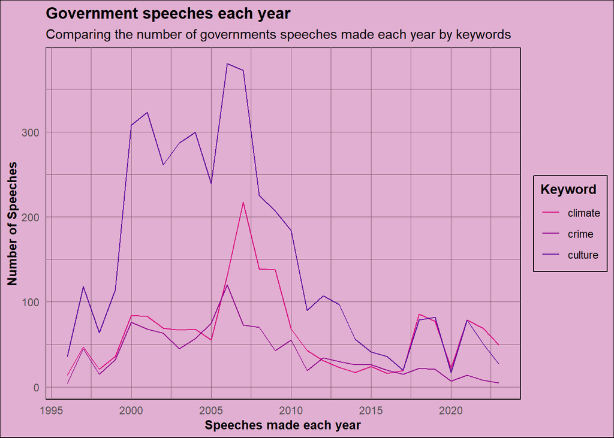

```r
library(tidyverse)
library(rvest)

keywords <- c("culture", "climate", "crime")

search1 <- read_html(paste0("https://datalandscapes.online/scrapeable/speeches.php?search=", keywords[1])) %>%
  html_elements(".speech_summary") %>%
  html_text2() %>%
  tibble(keyword = keywords[1],
         results = .) %>%
  separate(results, into = c("year", "num_speeches"), sep = "--") %>%
  mutate(num_speeches = parse_number(num_speeches),
         year = parse_number(year))

search2 <- read_html(paste0("https://datalandscapes.online/scrapeable/speeches.php?search=", keywords[2])) %>%
  html_elements(".speech_summary") %>%
  html_text2() %>%
  tibble(keyword = keywords[2],
         results = .) %>%
  separate(results, into = c("year", "num_speeches"), sep = "--") %>%
  mutate(num_speeches = parse_number(num_speeches),
         year = parse_number(year))

search3 <- read_html(paste0("https://datalandscapes.online/scrapeable/speeches.php?search=", keywords[3])) %>%
  html_elements(".speech_summary") %>%
  html_text2() %>%
  tibble(keyword = keywords[3],
         results = .) %>%
  separate(results, into = c("year", "num_speeches"), sep = "--") %>%
  mutate(num_speeches = parse_number(num_speeches),
         year = parse_number(year))

combined_searches <- bind_rows(search1,
                               search2,
                               search3)

speeches_governments <- read_csv("https://docs.google.com/spreadsheets/d/e/2PACX-1vRHTFJcFmsIkjaFUCEwFWASaBOAR4X2Upx66C5Bhgc_WNc2JxxdRbbvyoewmvt_EjNdCNZZzzkENwLg/pub?gid=0&single=true&output=csv")

speech_data <- left_join(combined_searches,
                         speeches_governments,
                         by = "year")

colour_palette = c("#610C9F", "#940B92", "#DA0C81", "#E1AFD1","#85586F")

plot <- ggplot(speech_data) +
  geom_line(aes(x = year,
                y = num_speeches,
                colour = keyword)) +
  labs(x = "Speeches made each year",
       y = "Number of Speeches",
       title = "Government speeches each year",
       colour = "Keyword",
       subtitle = "Comparing the number of governments speeches made each year by keywords") +
  theme_minimal() +
  theme(plot.title = element_text(face = 'bold'),
        plot.background = element_rect(fill = colour_palette[4]),
        panel.background = element_rect(fill = colour_palette[4]),
        panel.grid.major = element_line(colour = colour_palette[5], size = .2),
        panel.grid.minor = element_line(colour = colour_palette[5], size = .2),
        legend.title = element_text(face = "bold"),
        legend.background = element_rect(fill = colour_palette[4]),
        axis.title = element_text(face = 'bold', size = 10)) +
  scale_fill_manual(values = c("culture" = colour_palette[1],
                               "crime" = colour_palette[2],
                               "climate" = colour_palette[3])) +
  scale_colour_manual(values = c("culture" = colour_palette[1],
                               "crime" = colour_palette[2],
                               "climate" = colour_palette[3]))

plot
```

Speeches related to the keyword “culture” had a higher number of speeches than the number of speeches related to the keywords “climate” and “crime”.

## Learning Reflection

In Module 5, I understood the significance of data cleaning through string functions and tokens. While exploring my dataset, I recognised the vital role of data cleaning in precise analysis, enabling a more narrow exploration of relevant variables. I also found the Sentiment Analysis lexicon helpful for my analysis, as I understood how to match sentiments to the content I was exploring.

I found the filter() function helpful because it was invaluable for removing undesired values from observations. In the future, I’m keen to delve deeper into data mining beyond web scraping. Its broader applications and how it can enhance data exploration and analytical capabilities intrigue me.

## Self Review

The learning outcome, “Describe tidy data principles, grammar of data manipulation, and grammar of graphics,” was the most relevant to me. Particularly, throughout Projects 3 and 4, I learned to extract insights from text-based variables. Project 4 improved my ability to step outside my comfort zone and challenge myself to create variables requiring external resources to achieve my data goal. Still, I developed problem-solving skills during Project 4 and this current project due to the numerous trials and errors. For example, for this project in Part B, I learned later that when scraping for the release_count, I could have scraped first with html_elements(“.col-xs-12”) and then scraped with html_elements(“p”), which would have given me only the body of the content and no additional words that were redundant. However, I solved the problem by cleaning the data and applying the filter() function, so I’m glad I did it this way. I learned how to have the entire content variable correspond to the release article variable after getting data where the content was divided into many rows because it was split into sentences. This shows that I could develop problem-solving skills and persistence when I encountered many failed attempts.